# GAN_28x28x1_keras

## Creating Image using GAN

#### GAN.py 파일 import 하셔야합니다

```python
import os
import matplotlib.pyplot as plt
import numpy as np
from models.GAN import GAN
import os
from keras.models import load_model
from PIL import Image
import PIL
import imageio
import glob
from IPython import display

# it needs for graphviz, but idkw
os.environ["PATH"] += os.pathsep + 'C:/Program Files (x86)/Graphviz2.38/bin/'
```

```python
# run params
SECTION = 'gan'
RUN_ID = '0001'
DATA_NAME = 'camel'
RUN_FOLDER = 'C:/Users/MINSUNGKANG/MINSUNGKANGCODE/GAN/run/{}/'.format(SECTION)
RUN_FOLDER += '_'.join([RUN_ID, DATA_NAME])

if not os.path.exists(RUN_FOLDER):
    os.mkdir(RUN_FOLDER)
    os.mkdir(os.path.join(RUN_FOLDER, 'viz'))
    os.mkdir(os.path.join(RUN_FOLDER, 'images'))
    os.mkdir(os.path.join(RUN_FOLDER, 'weights'))

mode =  'build' #'load' #
```

### 1. Data Load & preprocessing

```python
# Data Load
# from quickdraw import data # (it's possible using library)

# get the data from here: https://console.cloud.google.com/storage/browser/quickdraw_dataset/full/numpy_bitmap
# 검색창에 camel이라 치시면 됩니다.

dataset = np.load('C:/Users/MINSUNGKANG/MINSUNGKANGCODE/data/full_numpy_bitmap_camel.npy')
x_train = dataset.reshape(121399,28,28,1)

# set fixel value as -1 ~ 1
x_train = (x_train - 127.5) / 127.5

# set fixel value as 0~1
# x_train = x_train/255
```

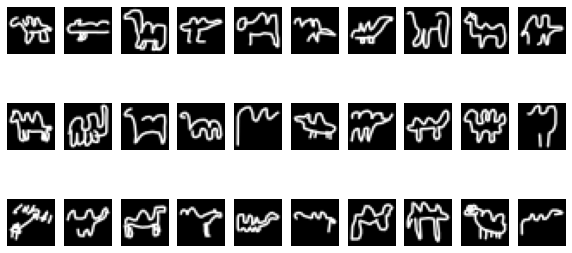

```python
# Display dataset

plt.figure(figsize=(10,5))
for i in range(30):
    rand = np.random.randint(0, len(x_train))
    plt.subplot(3,10,i+1)
    plt.axis('off')
    plt.imshow(x_train[rand,:,:,0], cmap = 'gray')
```

### 2. Build Model

```python
# build a model for 28*28*1

gan = GAN(input_dim = (28,28,1)
        , discriminator_conv_filters = [64,64,128,128]
        , discriminator_conv_kernel_size = [3,3,3,3]
        , discriminator_conv_strides = [2,2,2,1]
        , discriminator_batch_norm_momentum = 0.8
        , discriminator_activation = 'leaky_relu'
        , discriminator_dropout_rate = 0.4
        , discriminator_learning_rate = 0.0008
        , generator_initial_dense_layer_size = (7, 7, 64)
        , generator_upsample = [2,2, 1, 1]
        , generator_conv_filters = [128,64, 64,1]
        , generator_conv_kernel_size = [5,5,5,5]
        , generator_conv_strides = [1,1, 1, 1]
        , generator_batch_norm_momentum = 0.9
        , generator_activation = 'leaky_relu'
        , generator_dropout_rate = 0.4
        , generator_learning_rate = 0.0004
        , optimiser = 'adam'
        , z_dim = 100
        )

if mode == 'build':
    gan.save(RUN_FOLDER)
else:
    gan.load_weights(os.path.join(RUN_FOLDER, 'weights/weights.h5'))
```

```python
gan.generator.summary()
```

```
Model: "model_2"
_________________________________________________________________
Layer (type)                 Output Shape              Param #
=================================================================
generator_input (InputLayer) (None, 100)               0
_________________________________________________________________
dense_2 (Dense)              (None, 3136)              316736
_________________________________________________________________
batch_normalization_4 (Batch (None, 3136)              12544
_________________________________________________________________
leaky_re_lu_5 (LeakyReLU)    (None, 3136)              0
_________________________________________________________________
reshape_1 (Reshape)          (None, 7, 7, 64)          0
_________________________________________________________________
dropout_5 (Dropout)          (None, 7, 7, 64)          0
_________________________________________________________________
up_sampling2d_1 (UpSampling2 (None, 14, 14, 64)        0
_________________________________________________________________
generator_conv_0 (Conv2D)    (None, 14, 14, 128)       204928
_________________________________________________________________
batch_normalization_5 (Batch (None, 14, 14, 128)       512
_________________________________________________________________
leaky_re_lu_6 (LeakyReLU)    (None, 14, 14, 128)       0
_________________________________________________________________
up_sampling2d_2 (UpSampling2 (None, 28, 28, 128)       0
_________________________________________________________________
generator_conv_1 (Conv2D)    (None, 28, 28, 64)        204864
_________________________________________________________________
batch_normalization_6 (Batch (None, 28, 28, 64)        256
_________________________________________________________________
leaky_re_lu_7 (LeakyReLU)    (None, 28, 28, 64)        0
_________________________________________________________________
generator_conv_2 (Conv2DTran (None, 28, 28, 64)        102464
_________________________________________________________________
batch_normalization_7 (Batch (None, 28, 28, 64)        256
_________________________________________________________________
leaky_re_lu_8 (LeakyReLU)    (None, 28, 28, 64)        0
_________________________________________________________________
generator_conv_3 (Conv2DTran (None, 28, 28, 1)         1601
_________________________________________________________________
activation_1 (Activation)    (None, 28, 28, 1)         0
=================================================================
Total params: 844,161
Trainable params: 837,377
Non-trainable params: 6,784
_________________________________________________________________
```

```python
gan.discriminator.summary()
```

```
Model: "model_1"
_________________________________________________________________
Layer (type)                 Output Shape              Param #
=================================================================
discriminator_input (InputLa (None, 28, 28, 1)         0
_________________________________________________________________
discriminator_conv_0 (Conv2D (None, 14, 14, 64)        640
_________________________________________________________________
leaky_re_lu_1 (LeakyReLU)    (None, 14, 14, 64)        0
_________________________________________________________________
dropout_1 (Dropout)          (None, 14, 14, 64)        0
_________________________________________________________________
discriminator_conv_1 (Conv2D (None, 7, 7, 64)          36928
_________________________________________________________________
batch_normalization_1 (Batch (None, 7, 7, 64)          256
_________________________________________________________________
leaky_re_lu_2 (LeakyReLU)    (None, 7, 7, 64)          0
_________________________________________________________________
dropout_2 (Dropout)          (None, 7, 7, 64)          0
_________________________________________________________________
discriminator_conv_2 (Conv2D (None, 4, 4, 128)         73856
_________________________________________________________________
batch_normalization_2 (Batch (None, 4, 4, 128)         512
_________________________________________________________________
leaky_re_lu_3 (LeakyReLU)    (None, 4, 4, 128)         0
_________________________________________________________________
dropout_3 (Dropout)          (None, 4, 4, 128)         0
_________________________________________________________________
discriminator_conv_3 (Conv2D (None, 4, 4, 128)         147584
_________________________________________________________________
batch_normalization_3 (Batch (None, 4, 4, 128)         512
_________________________________________________________________
leaky_re_lu_4 (LeakyReLU)    (None, 4, 4, 128)         0
_________________________________________________________________
dropout_4 (Dropout)          (None, 4, 4, 128)         0
_________________________________________________________________
flatten_1 (Flatten)          (None, 2048)              0
_________________________________________________________________
dense_1 (Dense)              (None, 1)                 2049
=================================================================
Total params: 262,337
Trainable params: 261,697
Non-trainable params: 640
_________________________________________________________________
```

### 3. Train Data

```python
# set the params
BATCH_SIZE = 64
EPOCHS = 2000
PRINT_EVERY_N_BATCHES = 100
```

```python
# train model
gan.train(
    x_train
    , batch_size = BATCH_SIZE
    , epochs = EPOCHS
    , run_folder = RUN_FOLDER
    , print_every_n_batches = PRINT_EVERY_N_BATCHES
)
```

```
0 [D loss: (1.370)(R 0.641, F 2.098)] [D acc: (0.320)(0.625, 0.016)] [G loss: 0.453] [G acc: 0.844]
```

```
1 [D loss: (0.659)(R 0.210, F 1.108)] [D acc: (0.570)(0.984, 0.156)] [G loss: 1.017] [G acc: 0.266]
2 [D loss: (0.437)(R 0.397, F 0.477)] [D acc: (0.789)(0.828, 0.750)] [G loss: 1.321] [G acc: 0.234]
3 [D loss: (0.899)(R 0.443, F 1.355)] [D acc: (0.477)(0.828, 0.125)] [G loss: 2.245] [G acc: 0.031]
4 [D loss: (0.643)(R 0.638, F 0.649)] [D acc: (0.625)(0.672, 0.578)] [G loss: 2.353] [G acc: 0.031]
5 [D loss: (0.445)(R 0.834, F 0.055)] [D acc: (0.719)(0.438, 1.000)] [G loss: 1.369] [G acc: 0.203]
6 [D loss: (0.114)(R 0.163, F 0.066)] [D acc: (0.984)(0.969, 1.000)] [G loss: 0.335] [G acc: 0.859]
7 [D loss: (0.076)(R 0.055, F 0.098)] [D acc: (1.000)(1.000, 1.000)] [G loss: 0.092] [G acc: 0.984]
8 [D loss: (0.089)(R 0.050, F 0.128)] [D acc: (1.000)(1.000, 1.000)] [G loss: 0.075] [G acc: 1.000]
9 [D loss: (0.058)(R 0.079, F 0.037)] [D acc: (1.000)(1.000, 1.000)] [G loss: 0.139] [G acc: 0.984]
10 [D loss: (0.079)(R 0.062, F 0.096)] [D acc: (0.992)(1.000, 0.984)] [G loss: 0.199] [G acc: 0.953]
11 [D loss: (0.123)(R 0.201, F 0.045)] [D acc: (0.977)(0.953, 1.000)] [G loss: 0.064] [G acc: 0.984]
12 [D loss: (0.061)(R 0.062, F 0.061)] [D acc: (0.992)(1.000, 0.984)] [G loss: 0.079] [G acc: 1.000]
13 [D loss: (0.061)(R 0.117, F 0.006)] [D acc: (0.992)(0.984, 1.000)] [G loss: 0.026] [G acc: 1.000]
14 [D loss: (0.065)(R 0.049, F 0.080)] [D acc: (0.992)(0.984, 1.000)] [G loss: 0.071] [G acc: 0.984]
15 [D loss: (0.055)(R 0.109, F 0.000)] [D acc: (0.984)(0.969, 1.000)] [G loss: 0.026] [G acc: 1.000]
```

[output cut: 1984 more lines]

### 4. Results

#### 일반적인 모델은 loss를 최소화시키는 것이 좋다.

#### 하지만 generator는 discriminator에 의해서만 평가받는데, 이 discriminator가 동시에 계속 향상되기 때문에 다른 지점에서의 loss값끼리의 비교 할 수 없다.

#### 그렇기에 Epoch이 증가할수록 이미지 품질이 향상되지만, loss function은 계속 증가한다.

#### Generator의 loss 값은 generator의 성능과 Discriminator의 성능을 모두 포함해서 나타내지는 값이다.

#### 그런데 Discriminator가 더 빨리 안정화되기 때문에, generator의 loss는 계속해서 커질 수 밖에 없다.

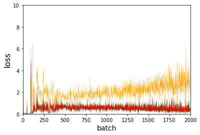

```python
# show loss function

fig = plt.figure()
plt.plot([x[0] for x in gan.d_losses], color='black', linewidth=0.25)

plt.plot([x[1] for x in gan.d_losses], color='green', linewidth=0.25)
plt.plot([x[2] for x in gan.d_losses], color='red', linewidth=0.25)
plt.plot([x[0] for x in gan.g_losses], color='orange', linewidth=0.25)

plt.xlabel('batch', fontsize=14)
plt.ylabel('loss', fontsize=16)

plt.xlim(0, 2000)
plt.ylim(0, 10)

plt.show()
```

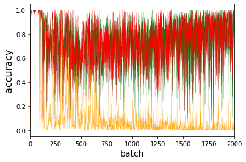

```python
fig = plt.figure()
plt.plot([x[3] for x in gan.d_losses], color='black', linewidth=0.25)
plt.plot([x[4] for x in gan.d_losses], color='green', linewidth=0.25)
plt.plot([x[5] for x in gan.d_losses], color='red', linewidth=0.25)
plt.plot([x[1] for x in gan.g_losses], color='orange', linewidth=0.25)

plt.xlabel('batch', fontsize=14)
plt.ylabel('accuracy', fontsize=16)

plt.xlim(0, 2000)

plt.show()
```

#### loss function이 500즈음까지는 계속 낮아지다 다시 상승하는 결과를 보인다.

#### Accuracy도 500즈음에서 가장 낮았다 다시 상승하는 결과를 보인다.

#### 하지만 이것이 epoch 500일 때 가장 좋은 모델을 생성한다 말할 수는 없다.

#### 원본과의 비교를 사람이 직접하여 더 좋은 모델을 선택해야 한다. (GAN은 확실한 평가 지표가 없다)

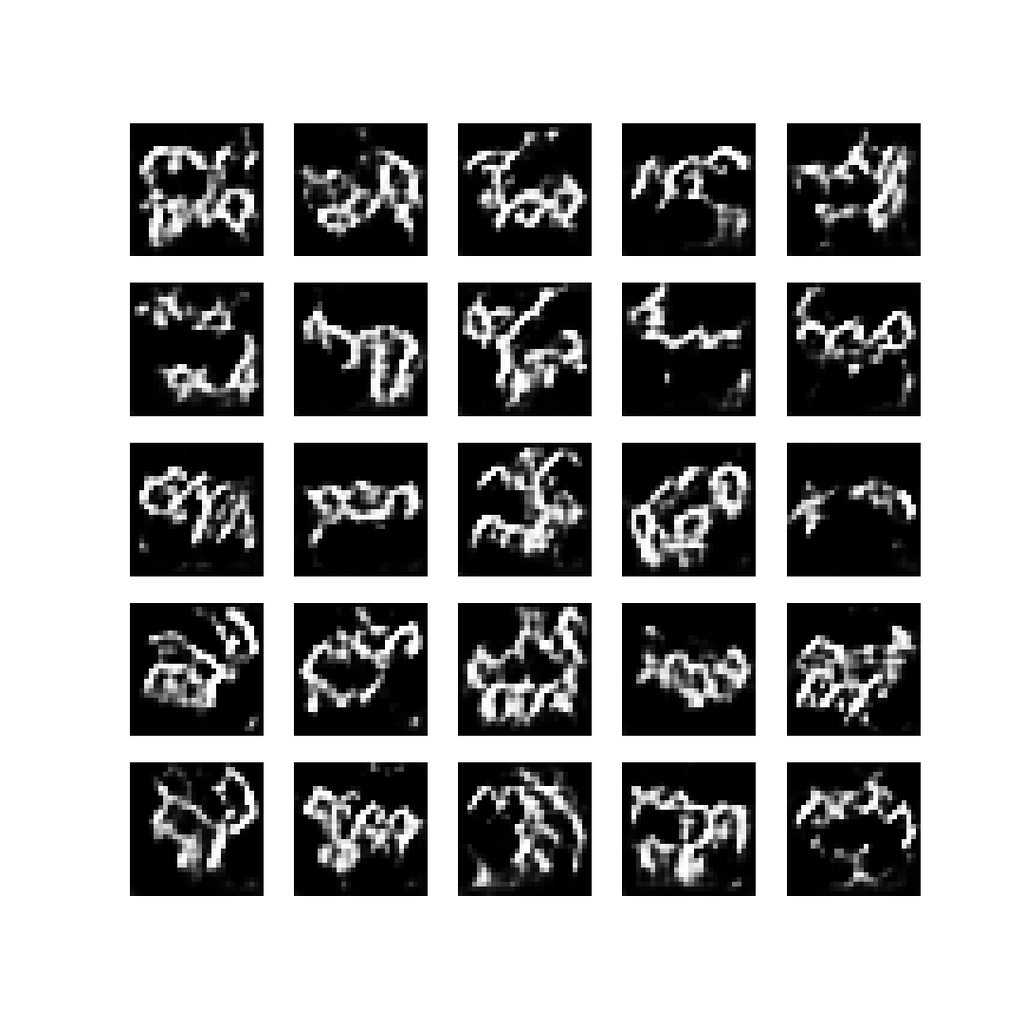

```python
# show result by epochs
def display_image(epoch_no):
    return PIL.Image.open('C:/Users/MINSUNGKANG/MINSUNGKANGCODE/GAN/run/gan/0001_camel/images/sample_{:d}.png'.format(epoch_no))

display_image(500)
```

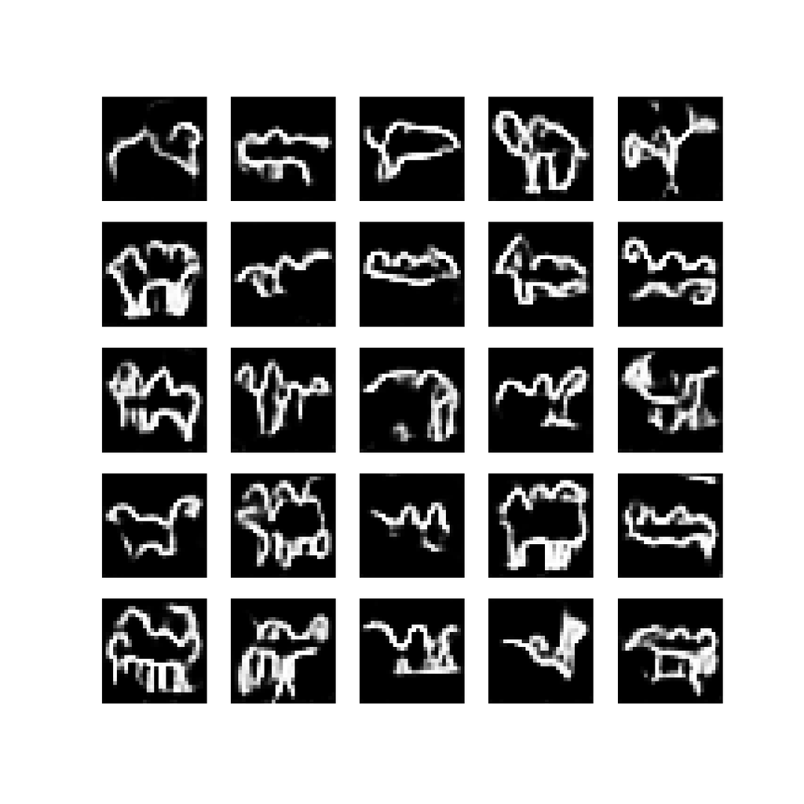

```python
display_image(1900)
```

```python
# make gif image
final_path = []
for i in range(0,EPOCHS,100):
    final_path.append('sample_' +str(i)+'.png')

path = [f"C:/Users/MINSUNGKANG/MINSUNGKANGCODE/GAN/run/gan/0001_camel/images/{i}" for i in final_path]
paths = [ Image.open(i) for i in path]

imageio.mimsave('C:/Users/MINSUNGKANG/MINSUNGKANGCODE/GAN/run/gan/0001_camel/test.gif', paths, fps=2)
```

```python
display.Image('C:/Users/MINSUNGKANG/MINSUNGKANGCODE/GAN/run/gan/0001_camel/test.gif')
```

[output not shown]

### 5. Generate Image Usnig GAN

```python
# generator_model makes a new image
# discriminator_model shows how many does a generated image looks like a real image

model = load_model('C:/Users/MINSUNGKANG/MINSUNGKANGCODE/GAN/run/gan/0001_camel/model.h5')
generator_model = load_model('C:/Users/MINSUNGKANG/MINSUNGKANGCODE/GAN/run/gan/0001_camel/generator.h5')
discriminator_model = load_model('C:/Users/MINSUNGKANG/MINSUNGKANGCODE/GAN/run/gan/0001_camel/discriminator.h5')
```

```python
# select generated image number
image_num = 64
noise = np.random.normal(0, 1, (image_num, 100))
```

```python
g_result = generator_model.predict(noise)
d_result = discriminator_model.predict(g_result)
```

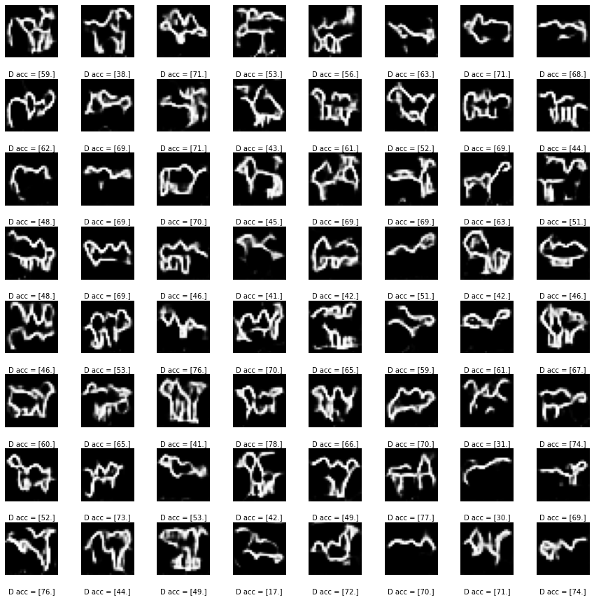

```python
# generated model list and the percentage of reality
fig = plt.figure(figsize=(15,15))
fig.subplots_adjust(hspace=0.4, wspace=0.4)

for i in range(64):
    ax = plt.subplot(8,8,i+1)
    ax.imshow(g_result[i,:,:,0], cmap='gray')
    ax.axis('off')
    d_accuracy = str((d_result[i]*100).round())
    ax.text(0.5,-0.35, 'D acc = '+ d_accuracy, fontsize=10, ha='center', transform=ax.transAxes)
```